# RNAseq Analysis PEC2

David Cartoixà Cartoixà

9/6/2020

**INDICE DE CONTENIDOS**

1.Abstract 2.Objetivo del estudio y datos 2.1.Objetivos del estudio 2.2.Preparación del entorno de trabajo 2.3.Selección de las muestras 3.Materiales y métodos 3.1.Creación del objeto DESeqDataSet 3.2.Filtrado de los datos 3.3.Estabilización de la varianza 3.4.Heatmap 3.5.Análisis de componentes principales 3.6.Análisis de expresión diferencial 3.7.Plot MA de comparación SFI vs NIT 3.8.Plot MA de comparación ELI vs NIT 3.9.Plot MA de comparación ELI vs SFI 3.10.Diagrama de Venn 3.11.Heatmap de los 10 genes más significativos 3.12.Anotación de los genes 3.13.Identificación de los genes 4.Discusión 5.Apéndice 6.Bibliografia

## 1.Abstract

En el presente estudio estudiaremos los perfiles de expresión a partir de los datos de expresión (RNAseq) pertenecientes a un análisis del tiroides den donde se comparan tres tipos de infiltración medido en un total de 292 muestras pertenecientes a tres grupos:

· Not infiltrated tissues (NIT): 236 muestras · Small focal infiltrates (SFI):42 muestras · Extensive lymphoid infiltrates (ELI): 14 muestras

Extraeremos al azar 10 muestras de cada grupo para estudiar si existen diferencias significativas entre ellos en cuanto a perfiles de expresión.

## 2.Objetivo del estudio y datos

## 2.1. Objetivos del estudio

Efectuaremos un análisis de los datos RNA-Seq de los tres grupos mencionados para determinar cuáles son los genes diferencialmente expresados entre los tres grupos.

## 2.2 Preparación del entorno de trabajo

Primeramente definiremos el directorio de trabajo, y crearemos tres carpetas: “data” donde almacenaremos los archivos .CEL descomprimidos y los archivos generados por nosotros target; una carpeta “results” donde registraremos los resultados obtenidos y finalmente la carpeta “figures” en la cual almacenaremos las figuras del estudio.

```r
> setwd(".")
> dir.create("data")
> dir.create("results")
> dir.create("figures")
```

## 2.3 Selección de las muestras

El archivo targets.csv y counts.csv contiene la información de las muestras de un estudio obtenido del repositorio (GTEx). Seleccionaremos 30 muestras aleatoriamente, 10 de cada grupo.

| Experiment | SRA_Sample | Sample_Name | Grupo_analisis | body_site | molecular_data_type | sex | Group | ShortName |
| --- | --- | --- | --- | --- | --- | --- | --- | --- |
| SRX567480 | SRS626942 | GTEX-111CU-0226-SM-5GZXC | 1 | Thyroid | Allele-Specific Expression | male | NIT | 111CU_NIT |
| SRX615964 | SRS644174 | GTEX-111FC-1026-SM-5GZX1 | 1 | Thyroid | RNA Seq (NGS) | male | NIT | 111FC_NIT |
| SRX563960 | SRS625636 | GTEX-111VG-0526-SM-5N9BW | 3 | Thyroid | RNA Seq (NGS) | male | ELI | 111VG_ELI |
| SRX564185 | SRS625665 | GTEX-111YS-0726-SM-5GZY8 | 1 | Thyroid | Allele-Specific Expression | male | NIT | 111YS_NIT |
| SRX559141 | SRS624025 | GTEX-1122O-0226-SM-5N9DA | 1 | Thyroid | RNA Seq (NGS) | female | NIT | 1122O_NIT |
| SRX561718 | SRS625313 | GTEX-1128S-0126-SM-5H12S | 1 | Thyroid | Allele-Specific Expression | female | NIT | 1128S_NIT |

[output not shown]

```r
> colnames(counts)<-gsub("[.]","-",colnames(counts))
```

Mediante la función sample seleccionaremos aletaoriamente 10 muestras de cada grupo, en nuestro caso sin reemplazamiento:

```r
> set.seed(1456)
> targets_NIT<- subset(targets, targets$Group == "NIT")
> targets_SFI<- subset(targets, targets$Group == "SFI")
> targets_ELI<- subset(targets, targets$Group == "ELI")
```

```r
> NIT_10<-targets_NIT[sample(1:nrow(targets_NIT),10),]
> SFI_10<-targets_SFI[sample(1:nrow(targets_SFI),10),]
> ELI_10<-targets_ELI[sample(1:nrow(targets_ELI),10),]
> targets_muestras<-rbind(NIT_10,SFI_10,ELI_10)
```

```r
> counts_muestras<-counts[,targets_muestras$Sample_Name]
> nombres_columnas <- c(paste("NIT", c(1:10), sep = "_"), paste("SFI", c(1:10), sep = "_"), paste("ELI", c(1:10), sep = "_"))
> colnames(counts_muestras) <- nombres_columnas
> coldata_muestras<-targets_muestras[,c("Group","Sample_Name")]
> head(coldata_muestras)
```

|  | Group | Sample_Name |
| --- | --- | --- |
| 273 | NIT | GTEX-ZTSS-0226-SM-59877 |
| 118 | NIT | GTEX-13QBU-0626-SM-5J2OG |
| 108 | NIT | GTEX-13OVG-0226-SM-5LU93 |
| 254 | NIT | GTEX-Z9EW-0226-SM-5CVM7 |
| 239 | NIT | GTEX-Y114-0626-SM-4TT98 |
| 91 | NIT | GTEX-13G51-1226-SM-5K7Z3 |

## 3.Materiales y métodos

## 3.1. Creación del objeto DESeqDataSet

Construiremos el objeto DESeqDataSet a partir de los datos generados counts_muestras y coldata_muestras.

## 3.2.Filtrado de los datos

```r
> dds<-dds[rowSums(counts(dds))>=5,]
> nrow(dds)
```

```
[1] 39443
```

De 56202 gracias al prefiltrado obtenemos 39443 genes

## 3.3.Estabilización de la varianza

Efectuaremos un proceso de normalización con el método VST (variancde stabilizaing transformation) generando el objeto “vsd”

```r
> vsd<-vst(dds,blind=FALSE)
> head(assay(vsd),3)
```

|  | NIT_1 | NIT_2 | NIT_3 | NIT_4 | NIT_5 | NIT_6 | NIT_7 | NIT_8 | NIT_9 | NIT_10 | SFI_1 | SFI_2 | SFI_3 | SFI_4 | SFI_5 | SFI_6 | SFI_7 | SFI_8 | SFI_9 | SFI_10 | ELI_1 | ELI_2 | ELI_3 | ELI_4 | ELI_5 | ELI_6 | ELI_7 | ELI_8 | ELI_9 | … |
| --- | --- | --- | --- | --- | --- | --- | --- | --- | --- | --- | --- | --- | --- | --- | --- | --- | --- | --- | --- | --- | --- | --- | --- | --- | --- | --- | --- | --- | --- | --- |
| ENSG00000223972.4 | 4.170073 | 4.539828 | 4.286196 | 4.195691 | 4.105029 | 3.322989 | 5.263607 | 3.993651 | 3.322989 | 4.032690 | 3.781557 | 4.306126 | 3.965362 | 4.227092 | 4.842906 | 3.947565 | 4.318904 | 3.322989 | 3.322989 | 4.092266 | 4.482776 | 4.057400 | 3.974244 | 3.322989 | 4.029245 | 3.322989 | 4.713770 | 4.083775 | 3.675591 | … |
| ENSG00000227232.4 | 9.555407 | 9.588038 | 9.734627 | 9.194952 | 9.473535 | 10.231476 | 9.030215 | 8.886862 | 9.931201 | 9.903944 | 10.109551 | 9.063448 | 9.481267 | 9.166834 | 8.742371 | 10.105921 | 9.639467 | 9.227447 | 9.534737 | 8.865806 | 10.180591 | 9.809989 | 9.444452 | 8.905125 | 9.069501 | 9.853578 | 8.871565 | 10.293480 | 9.820539 | … |
| ENSG00000243485.2 | 3.322989 | 3.322989 | 4.010282 | 4.039087 | 4.222468 | 3.849276 | 4.399507 | 3.322989 | 3.322989 | 3.615153 | 3.968830 | 4.130747 | 3.965362 | 3.322989 | 4.361232 | 3.685456 | 3.322989 | 3.796425 | 3.322989 | 3.322989 | 3.807049 | 3.693156 | 3.974244 | 3.322989 | 3.322989 | 3.798555 | 4.146199 | 3.765598 | 3.675591 | … |

```r
> vsd
```

```
class: DESeqTransform
dim: 39443 30
metadata(1): version
assays(1): ''
rownames(39443): ENSG00000223972.4 ENSG00000227232.4 ...
  ENSG00000210195.2 ENSG00000210196.2
rowData names(5): genes baseMean baseVar allZero dispFit
colnames(30): NIT_1 NIT_2 ... ELI_9 ELI_10
colData names(3): Group Sample_Name sizeFactor
```

## 3.4.Heatmap

Con el objeto vsd genearmos un heatmap para visualizar las distancias entre las muestras, a mayor tonalidad mayor proximidad.

```r
> sampleDists<-dist(t(assay(vsd)))
```

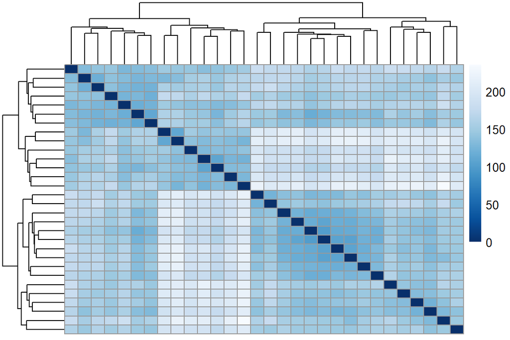

Figura 1.Heatmap de la agupación entre muestras

```r
> library("pheatmap")
> library("RColorBrewer")
> sampleDistMatrix <- as.matrix( sampleDists )
> rownames(sampleDistMatrix) <- paste( vsd$dex, vsd$cell, sep = " - " )
> colnames(sampleDistMatrix) <- NULL
> colors <- colorRampPalette( rev(brewer.pal(9, "Blues")) )(255)
> pheatmap(sampleDistMatrix,
+          clustering_distance_rows = sampleDists,
+          clustering_distance_cols = sampleDists,
+          col = colors)
```

## 3.5. Análisis de componentes principales (PCA)

Gracias al gráfico PCA observamos la distribución de los tres grupos.

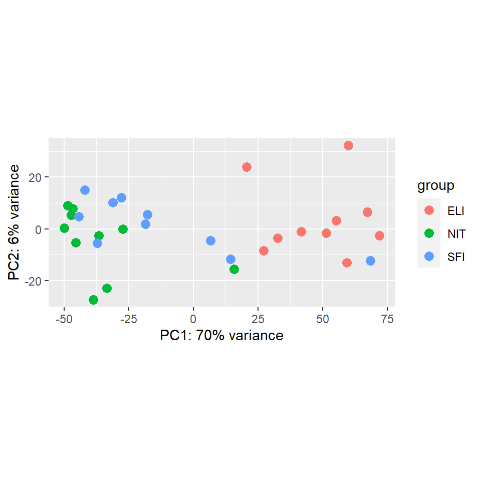

Figura 2.Análisis de componentes principales

```r
> library(DESeq2)
> plotPCA(vsd, intgroup = c("Group"))
```

En la figura vemos que el primer componente (PC1)representa el 70% de la variabilidad total, mientras que el segundo componente (PC2) acumula el 6% de los datos normalizados.

## 3.6.Análisis de expresión diferencial

Para realizar el análisis de expresión deiferencial emplearemos la función DeSeq() de la libreria DESeq2 con los datos filtrados. El análisis de expresión génica se llevará a cabo basandonos en la distribución bionmial negativa

```r
> library(DESeq2)
> dds <- DESeq(dds, parallel =TRUE)
> res <- results(dds)
> summary(res)
```

```
out of 39438 with nonzero total read count
adjusted p-value < 0.1
LFC > 0 (up)       : 2375, 6%
LFC < 0 (down)     : 3097, 7.9%
outliers [1]       : 0, 0%
low counts [2]     : 9945, 25%
(mean count < 1)
[1] see 'cooksCutoff' argument of ?results
[2] see 'independentFiltering' argument of ?results
```

## 3.7.Plot MA de comparación SFI vs NIT

Obtenemos la tabla de resultados de la comparación SFI vs NIT

```r
> sfi_nit<-results(dds,contrast=c("Group","SFI","NIT"),alpha=0.05)
> summary(sfi_nit)
```

```
out of 39438 with nonzero total read count
adjusted p-value < 0.05
LFC > 0 (up)       : 375, 0.95%
LFC < 0 (down)     : 71, 0.18%
outliers [1]       : 0, 0%
low counts [2]     : 14533, 37%
(mean count < 5)
[1] see 'cooksCutoff' argument of ?results
[2] see 'independentFiltering' argument of ?results
```

```r
> table(sfi_nit$adj<0.05)
```

```
Empty table
```

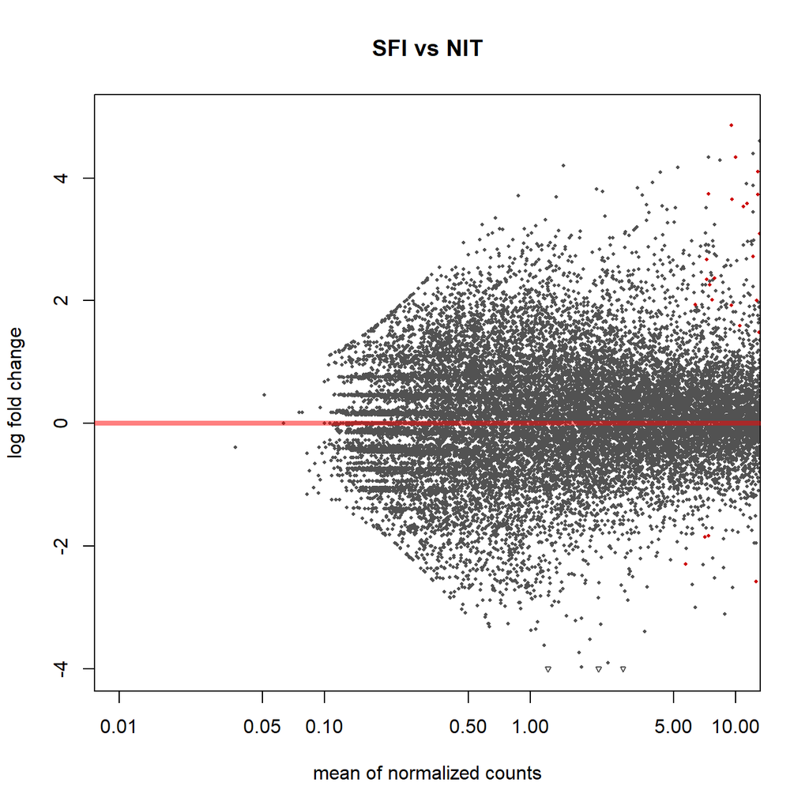

Figura 3.Comparación SFI vs NIT

## 3.8. Plot MA de omparación ELI vs NIT

```r
> eli_nit<-results(dds,contrast=c("Group","ELI","NIT"),alpha=0.05)
> summary(eli_nit)
```

```
out of 39438 with nonzero total read count
adjusted p-value < 0.05
LFC > 0 (up)       : 4271, 11%
LFC < 0 (down)     : 2411, 6.1%
outliers [1]       : 0, 0%
low counts [2]     : 8416, 21%
(mean count < 1)
[1] see 'cooksCutoff' argument of ?results
[2] see 'independentFiltering' argument of ?results
```

```r
> table(eli_nit$adj<0.05)
```

```
Empty table
```

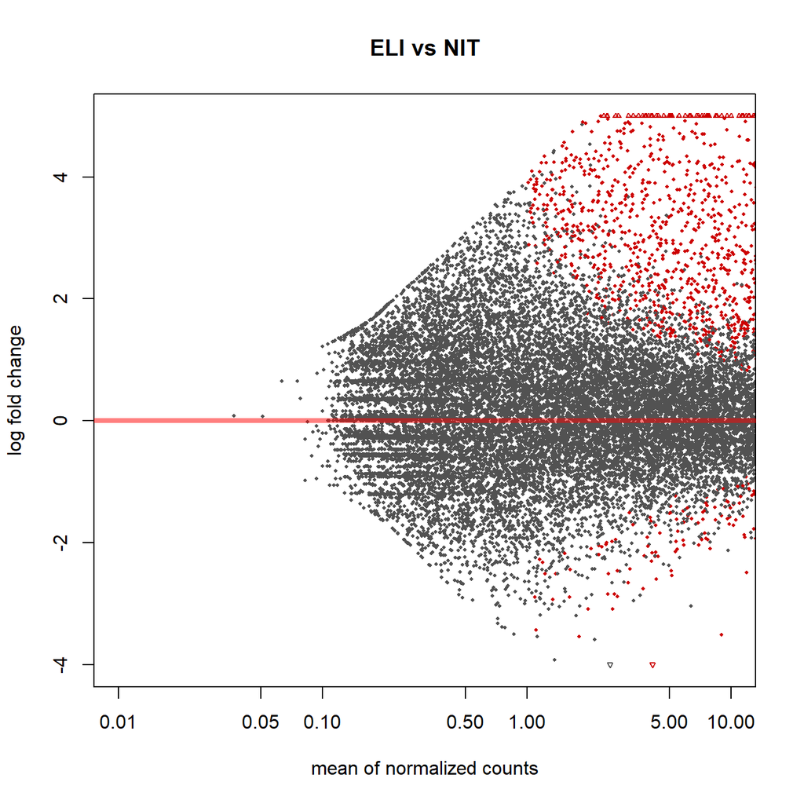

Figura 4.Comparación ELI vs NIT

```r
> eli_sfi<-results(dds,contrast=c("Group","ELI","SFI"),alpha=0.05)
> summary(eli_sfi)
```

```
out of 39438 with nonzero total read count
adjusted p-value < 0.05
LFC > 0 (up)       : 2373, 6%
LFC < 0 (down)     : 1615, 4.1%
outliers [1]       : 0, 0%
low counts [2]     : 10710, 27%
(mean count < 2)
[1] see 'cooksCutoff' argument of ?results
[2] see 'independentFiltering' argument of ?results
```

```r
> table(eli_sfi$adj<0.05)
```

```
Empty table
```

## 3.9 Plot MA de comparación ELI vs SFI

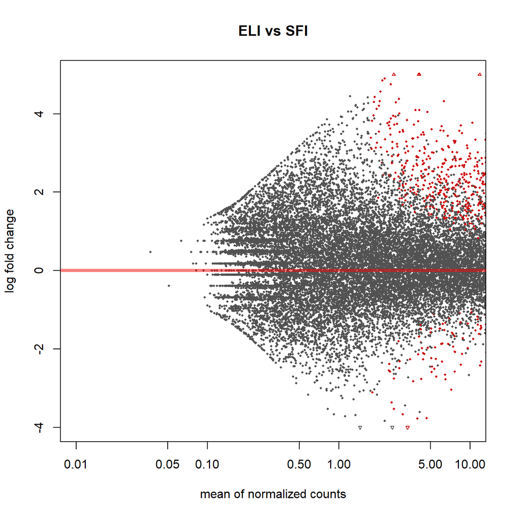

Figura 5.Comparación ELI vs SFI

En los tres gráficos observamos diferencias entre las comparaciones, siendo las dos últimas donde existe una mayor sobreexpresión génica.

## 3.10. Diagrama de Venn

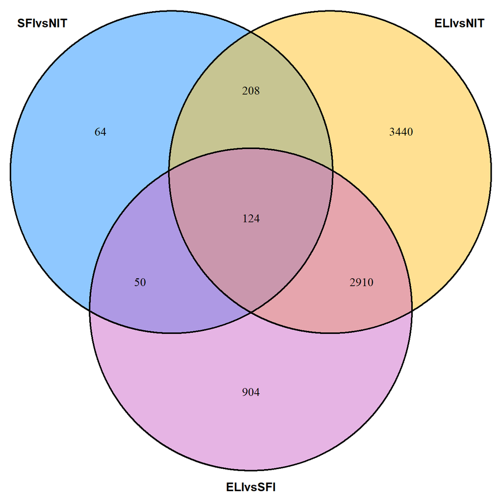

Figura 6.Diagrama de Venn de las tres comparaciones

El Diagrama de Venn nos permite de una manera muy visual ver el número de genes en común que hay entre las tres comparaciones.

## 3.11 Heatmap de los 10 genes más significativos

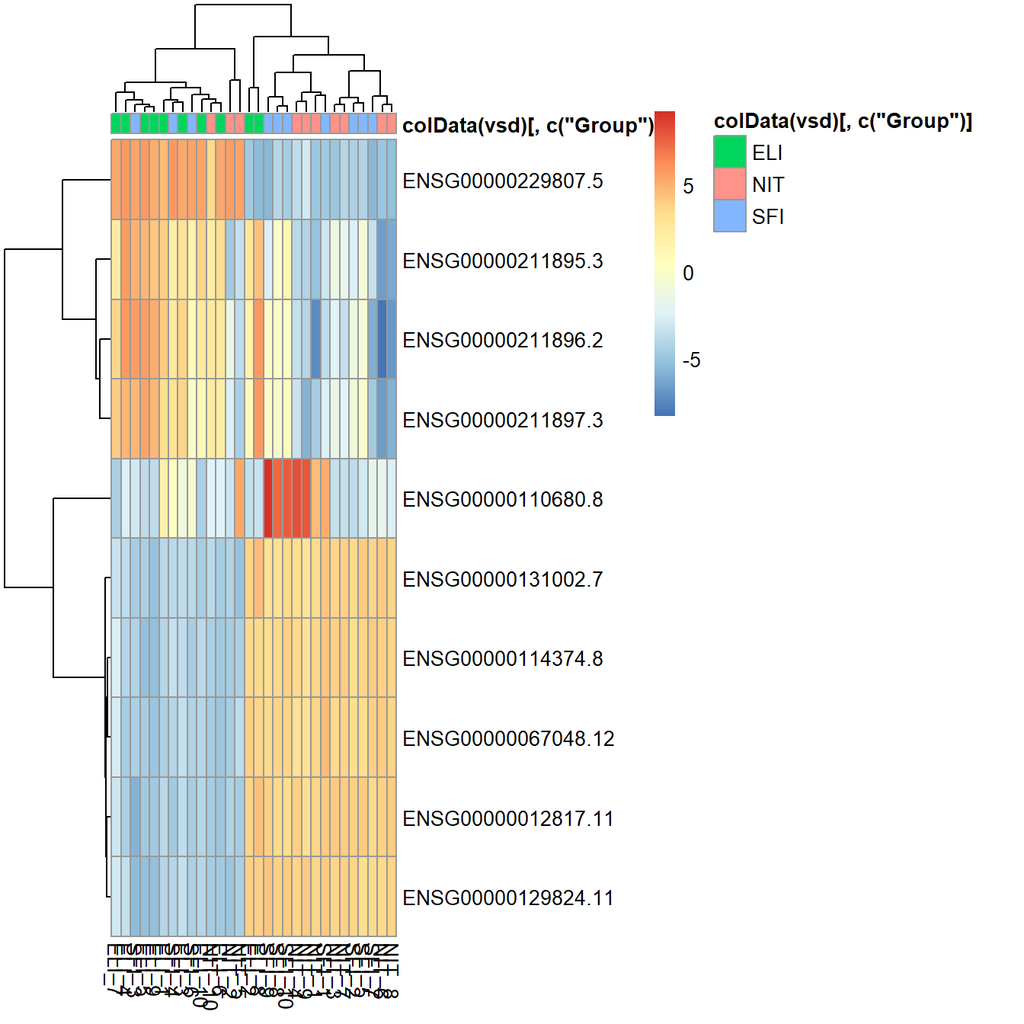

Figura 7.Heatmap con los 10 genes más significativos

El heatmap nos permite ver las diferencias a nivel de expresión de los 10 genes más significativos de los tres grupos.

## 3.12.Anotación de los genes

```r
> library("AnnotationDbi")
> library("org.Hs.eg.db")
> columns(org.Hs.eg.db)
```

```
 [1] "ACCNUM"       "ALIAS"        "ENSEMBL"      "ENSEMBLPROT"  "ENSEMBLTRANS"
 [6] "ENTREZID"     "ENZYME"       "EVIDENCE"     "EVIDENCEALL"  "GENENAME"
[11] "GO"           "GOALL"        "IPI"          "MAP"          "OMIM"
[16] "ONTOLOGY"     "ONTOLOGYALL"  "PATH"         "PFAM"         "PMID"
[21] "PROSITE"      "REFSEQ"       "SYMBOL"       "UCSCKG"       "UNIGENE"
[26] "UNIPROT"
```

```r
> sfi_nit$symbol <- mapIds(org.Hs.eg.db,
+                      keys=gsub("\\..*", "", row.names(sfi_nit), fixed = FALSE),
+                      column="SYMBOL",
+                      keytype="ENSEMBL",
+                      multiVals="first")
> sfi_nit$entrez <- mapIds(org.Hs.eg.db,
+                      keys=gsub("\\..*", "", row.names(sfi_nit), fixed = FALSE),
+                      column="ENTREZID",
+                      keytype="ENSEMBL",
+                      multiVals="first")
> resOrdered1 <- sfi_nit[order(sfi_nit$pvalue),]
> head(resOrdered1)
```

```
log2 fold change (MLE): Group SFI vs NIT
Wald test p-value: Group SFI vs NIT
DataFrame with 6 rows and 8 columns
                           baseMean   log2FoldChange             lfcSE
                          <numeric>        <numeric>         <numeric>
ENSG00000211892.2  13492.4172432439 6.07362956218868 0.968748372269586
ENSG00000172724.7  3719.51961557336 3.62230886704793 0.660502537698542
ENSG00000260997.1  184.416184325258 2.86548472807048 0.526025005761084
ENSG00000159958.3  246.757022074058 4.78458849861988 0.888062802466163
ENSG00000136286.10 1702.74944724437 2.32995837029841  0.43741940954848
ENSG00000269404.2  479.721611955277 3.93406065863648 0.747975343019807
                               stat               pvalue                 padj
                          <numeric>            <numeric>            <numeric>
ENSG00000211892.2  6.26956363081092 3.62061318140653e-10 9.01894743488367e-06
ENSG00000172724.7  5.48417100662402 4.15412786374104e-08 0.000424322218846931
ENSG00000260997.1   5.4474306291286 5.11026357503329e-08 0.000424322218846931
ENSG00000159958.3  5.38766907625565 7.13773185228306e-08 0.000444502251100928
ENSG00000136286.10 5.32660032782604 1.00068017826303e-07 0.000498538864810644
ENSG00000269404.2  5.25961276043333 1.44359083688796e-07 0.000599330795781319
                        symbol      entrez
                   <character> <character>
ENSG00000211892.2           NA          NA
ENSG00000172724.7        CCL19        6363
ENSG00000260997.1           NA          NA
ENSG00000159958.3    TNFRSF13C      115650
ENSG00000136286.10       MYO1G       64005
ENSG00000269404.2         SPIB        6689
```

```r
> resOrderedDF <- as.data.frame(resOrdered1)
> write.csv(resOrderedDF, file = "results1.csv")
```

```r
> library("AnnotationDbi")
> library("org.Hs.eg.db")
> columns(org.Hs.eg.db)
```

```
 [1] "ACCNUM"       "ALIAS"        "ENSEMBL"      "ENSEMBLPROT"  "ENSEMBLTRANS"
 [6] "ENTREZID"     "ENZYME"       "EVIDENCE"     "EVIDENCEALL"  "GENENAME"
[11] "GO"           "GOALL"        "IPI"          "MAP"          "OMIM"
[16] "ONTOLOGY"     "ONTOLOGYALL"  "PATH"         "PFAM"         "PMID"
[21] "PROSITE"      "REFSEQ"       "SYMBOL"       "UCSCKG"       "UNIGENE"
[26] "UNIPROT"
```

```r
> eli_nit$symbol <- mapIds(org.Hs.eg.db,
+                      keys=gsub("\\..*", "", row.names(sfi_nit), fixed = FALSE),
+                      column="SYMBOL",
+                      keytype="ENSEMBL",
+                      multiVals="first")
> eli_nit$entrez <- mapIds(org.Hs.eg.db,
+                      keys=gsub("\\..*", "", row.names(sfi_nit), fixed = FALSE),
+                      column="ENTREZID",
+                      keytype="ENSEMBL",
+                      multiVals="first")
> resOrdered2 <- eli_nit[order(eli_nit$pvalue),]
> head(resOrdered2)
```

```
log2 fold change (MLE): Group ELI vs NIT
Wald test p-value: Group ELI vs NIT
DataFrame with 6 rows and 8 columns
                           baseMean    log2FoldChange             lfcSE
                          <numeric>         <numeric>         <numeric>
ENSG00000262222.1  184.422737861042   2.7511097591949 0.273213131856316
ENSG00000104921.10 405.807330008998  6.43550005006524 0.664359071143536
ENSG00000167483.13 1016.63079282833  7.05313690130025 0.768618871960019
ENSG00000112763.11 3145.06226024024 0.944831745419756 0.103874586459125
ENSG00000072818.7  3093.36286537535  3.78700962883201 0.418212018355202
ENSG00000233355.2   380.21804207831  5.22810933551214 0.578420130072726
                               stat               pvalue                 padj
                          <numeric>            <numeric>            <numeric>
ENSG00000262222.1  10.0694638669188 7.53879030167126e-24 2.33906046689954e-19
ENSG00000104921.10  9.6867798297509 3.43178248793211e-22 5.32389576265347e-18
ENSG00000167483.13 9.17637747212006 4.45837384285064e-20 4.61099884073756e-16
ENSG00000112763.11 9.09588935684041 9.38154732636207e-20  7.2770317223759e-16
ENSG00000072818.7  9.05523864121851  1.3626948428393e-19 8.20603279631975e-16
ENSG00000233355.2  9.03860198443439 1.58688228890703e-19 8.20603279631975e-16
                        symbol      entrez
                   <character> <character>
ENSG00000262222.1           NA          NA
ENSG00000104921.10       FCER2        2208
ENSG00000167483.13      NIBAN3      199786
ENSG00000112763.11      BTN2A1       11120
ENSG00000072818.7        ACAP1        9744
ENSG00000233355.2    CHRM3-AS2   100506915
```

```r
> resOrderedDF2 <- as.data.frame(resOrdered2)
> write.csv(resOrderedDF, file = "results2.csv")
```

```r
> library("AnnotationDbi")
> library("org.Hs.eg.db")
> columns(org.Hs.eg.db)
```

```
 [1] "ACCNUM"       "ALIAS"        "ENSEMBL"      "ENSEMBLPROT"  "ENSEMBLTRANS"
 [6] "ENTREZID"     "ENZYME"       "EVIDENCE"     "EVIDENCEALL"  "GENENAME"
[11] "GO"           "GOALL"        "IPI"          "MAP"          "OMIM"
[16] "ONTOLOGY"     "ONTOLOGYALL"  "PATH"         "PFAM"         "PMID"
[21] "PROSITE"      "REFSEQ"       "SYMBOL"       "UCSCKG"       "UNIGENE"
[26] "UNIPROT"
```

```r
> eli_sfi$symbol <- mapIds(org.Hs.eg.db,
+                      keys=gsub("\\..*", "", row.names(sfi_nit), fixed = FALSE),
+                      column="SYMBOL",
+                      keytype="ENSEMBL",
+                      multiVals="first")
> eli_sfi$entrez <- mapIds(org.Hs.eg.db,
+                      keys=gsub("\\..*", "", row.names(sfi_nit), fixed = FALSE),
+                      column="ENTREZID",
+                      keytype="ENSEMBL",
+                      multiVals="first")
> resOrdered3 <- eli_sfi[order(eli_sfi$pvalue),]
> head(resOrdered3)
```

```
log2 fold change (MLE): Group ELI vs SFI
Wald test p-value: Group ELI vs SFI
DataFrame with 6 rows and 8 columns
                           baseMean     log2FoldChange             lfcSE
                          <numeric>          <numeric>         <numeric>
ENSG00000262222.1  184.422737861042   1.98045214517335 0.270062285445374
ENSG00000168615.7   4006.5753536885 -0.732575581894148 0.105064248392268
ENSG00000162897.10 72.1494679582417   8.91932318299044  1.31626493299953
ENSG00000211979.2  17.7329282834744   7.13866465737796  1.07905685303743
ENSG00000154165.3  101.242768338442   4.54876530114955 0.702495357725913
ENSG00000176105.9  2365.18459210896 -0.766680718940675 0.118493377511733
                                stat               pvalue                 padj
                           <numeric>            <numeric>            <numeric>
ENSG00000262222.1   7.33331624557383 2.24526264326694e-13 6.45131315289889e-09
ENSG00000168615.7   -6.9726438165626 3.11039420963221e-12 4.46854784126811e-08
ENSG00000162897.10  6.77623703205778 1.23346254186967e-11 1.18136930718471e-07
ENSG00000211979.2   6.61565202730827 3.69917595993817e-11 2.65721057142258e-07
ENSG00000154165.3   6.47515353820217 9.47155790056187e-11 4.68571443486195e-07
ENSG00000176105.9  -6.47024108047522 9.78466801558199e-11 4.68571443486195e-07
                        symbol      entrez
                   <character> <character>
ENSG00000262222.1           NA          NA
ENSG00000168615.7        ADAM9        8754
ENSG00000162897.10       FCAMR       83953
ENSG00000211979.2           NA          NA
ENSG00000154165.3        GPR15        2838
ENSG00000176105.9         YES1        7525
```

```r
> resOrderedDF3 <- as.data.frame(resOrdered3)
> write.csv(resOrderedDF, file = "results3.csv")
```

## 3.13. Identificación de los genes

```
log2 fold change (MLE): Group SFI vs NIT
Wald test p-value: Group SFI vs NIT
DataFrame with 5 rows and 8 columns
                           baseMean   log2FoldChange             lfcSE
                          <numeric>        <numeric>         <numeric>
ENSG00000211892.2  13492.4172432439 6.07362956218868 0.968748372269586
ENSG00000172724.7  3719.51961557336 3.62230886704793 0.660502537698542
ENSG00000260997.1  184.416184325258 2.86548472807048 0.526025005761084
ENSG00000159958.3  246.757022074058 4.78458849861988 0.888062802466163
ENSG00000136286.10 1702.74944724437 2.32995837029841  0.43741940954848
                               stat               pvalue                 padj
                          <numeric>            <numeric>            <numeric>
ENSG00000211892.2  6.26956363081092 3.62061318140653e-10 9.01894743488367e-06
ENSG00000172724.7  5.48417100662402 4.15412786374104e-08 0.000424322218846931
ENSG00000260997.1   5.4474306291286 5.11026357503329e-08 0.000424322218846931
ENSG00000159958.3  5.38766907625565 7.13773185228306e-08 0.000444502251100928
ENSG00000136286.10 5.32660032782604 1.00068017826303e-07 0.000498538864810644
                        symbol      entrez
                   <character> <character>
ENSG00000211892.2           NA          NA
ENSG00000172724.7        CCL19        6363
ENSG00000260997.1           NA          NA
ENSG00000159958.3    TNFRSF13C      115650
ENSG00000136286.10       MYO1G       64005
```

```
log2 fold change (MLE): Group ELI vs NIT
Wald test p-value: Group ELI vs NIT
DataFrame with 5 rows and 8 columns
                           baseMean    log2FoldChange             lfcSE
                          <numeric>         <numeric>         <numeric>
ENSG00000262222.1  184.422737861042   2.7511097591949 0.273213131856316
ENSG00000104921.10 405.807330008998  6.43550005006524 0.664359071143536
ENSG00000167483.13 1016.63079282833  7.05313690130025 0.768618871960019
ENSG00000112763.11 3145.06226024024 0.944831745419756 0.103874586459125
ENSG00000072818.7  3093.36286537535  3.78700962883201 0.418212018355202
                               stat               pvalue                 padj
                          <numeric>            <numeric>            <numeric>
ENSG00000262222.1  10.0694638669188 7.53879030167126e-24 2.33906046689954e-19
ENSG00000104921.10  9.6867798297509 3.43178248793211e-22 5.32389576265347e-18
ENSG00000167483.13 9.17637747212006 4.45837384285064e-20 4.61099884073756e-16
ENSG00000112763.11 9.09588935684041 9.38154732636207e-20  7.2770317223759e-16
ENSG00000072818.7  9.05523864121851  1.3626948428393e-19 8.20603279631975e-16
                        symbol      entrez
                   <character> <character>
ENSG00000262222.1           NA          NA
ENSG00000104921.10       FCER2        2208
ENSG00000167483.13      NIBAN3      199786
ENSG00000112763.11      BTN2A1       11120
ENSG00000072818.7        ACAP1        9744
```

```
log2 fold change (MLE): Group ELI vs SFI
Wald test p-value: Group ELI vs SFI
DataFrame with 5 rows and 8 columns
                           baseMean     log2FoldChange             lfcSE
                          <numeric>          <numeric>         <numeric>
ENSG00000262222.1  184.422737861042   1.98045214517335 0.270062285445374
ENSG00000168615.7   4006.5753536885 -0.732575581894148 0.105064248392268
ENSG00000162897.10 72.1494679582417   8.91932318299044  1.31626493299953
ENSG00000211979.2  17.7329282834744   7.13866465737796  1.07905685303743
ENSG00000154165.3  101.242768338442   4.54876530114955 0.702495357725913
                               stat               pvalue                 padj
                          <numeric>            <numeric>            <numeric>
ENSG00000262222.1  7.33331624557383 2.24526264326694e-13 6.45131315289889e-09
ENSG00000168615.7  -6.9726438165626 3.11039420963221e-12 4.46854784126811e-08
ENSG00000162897.10 6.77623703205778 1.23346254186967e-11 1.18136930718471e-07
ENSG00000211979.2  6.61565202730827 3.69917595993817e-11 2.65721057142258e-07
ENSG00000154165.3  6.47515353820217 9.47155790056187e-11 4.68571443486195e-07
                        symbol      entrez
                   <character> <character>
ENSG00000262222.1           NA          NA
ENSG00000168615.7        ADAM9        8754
ENSG00000162897.10       FCAMR       83953
ENSG00000211979.2           NA          NA
ENSG00000154165.3        GPR15        2838
```

## 4.Discusión

En el informe se ha trabajado con una gran cantidad de genes que presentan diferente expresión según la infiltración efectuada. Se nos ha proporcionado unos datos preprocesados en una tabla de contajes y extraerlos de forma aleatoria para que tengamos un número cómodo de muestras para analizar y que la complejidad del estudio y realización de la pec no sea tan árdua, en contrapartida el trabajar con pocas muestras es menos correcto estadísticamente.

Técnicamente hemos tenido problemas para efectuar la parte de significación biológica y no hemos podido completar el estudio totalmente, concretamente nos ha sido imposible que la libreria ReactomePA nos funcionara.

## 5.Apéndice

El siguiente informe, código y datos generados en este trabajo se pueden encontrar en el repositorio [https://github.com/dcc1978/PEC2-RNAseq]

## 6.Bibliografia

https://github.com/ASPteaching/Omics_data_analysis-Case_study_2-RNA-seq

Introduction to DGE: Normalization. https://hbctraining.github.io/DGE_workshop/lessons/02_DGE_count_normalization.html

Introduction to DGE: Differential expression analysis with DESeq2. https://hbctraining.github.io/DGE_workshop/lessons/04_DGE_DESeq2_analysis.html

Introduction to DGE: Functional analysis. https://hbctraining.github.io/DGE_workshop/lessons/09_functional_analysis.html

Love MI, Anders S, Huber W (2020). “Analyzing RNA-seq data with DESeq2”.